# Pobreza vieja metodologia deteccion de un error

Christian Castro

DataIntelligence

2022-02-15

Abstract

Detectamos un error en el calculo de la cantidad de pobres en los años 2006, 2009 y 2011

# 1 Introducción

En éste trabajo nos concentraremos en la distribución de la pobreza en Chile, pobreza que se divide en tres grandes grupos: no pobres, pobres y pobres extremos.

Veremos que para cifras del año y a nivel regional, los cálculos a los que llegamos son exactos a los obtenidos y publicados por Casen en cada año en que fue aplicada. Pero hay un problema: las cifras entregadas en los gobiernos de Bachelet y Piñera (2006,2009,2011) fueron corregidos según una nueva metodología que no conocemos.

Los análisis oficiales que entrega Casen y que son descargables de [aquí](http://observatorio.ministeriodesarrollosocial.gob.cl/encuesta-casen-en-pandemia-2020) para el 2020 y de [aquí](http://observatorio.ministeriodesarrollosocial.gob.cl/encuesta-casen-2011) del 2011 hasta 1990, entregan estadísticas muy útiles sobres las cuales comparar.

# 2 Leemos las bases de datos con nuestras variables basicas homologadas y las hacemos caracteres:

```r
casen_2006 <- readRDS("C:/Users/chris/Desktop/algoritmos generadores de ttcc v 3.0/casens_homologadas/casen_2006_homologado.rds")
casen_2006 <- mutate_if(casen_2006, is.factor, as.character)

casen_2009 <- readRDS("C:/Users/chris/Desktop/algoritmos generadores de ttcc v 3.0/casens_homologadas/casen_2009_homologado.rds")
casen_2009 <- mutate_if(casen_2009, is.factor, as.character)

casen_2011 <- readRDS("C:/Users/chris/Desktop/algoritmos generadores de ttcc v 3.0/casens_homologadas/casen_2011_homologado.rds")
casen_2011 <- mutate_if(casen_2011, is.factor, as.character)

casen_2013 <- readRDS("C:/Users/chris/Desktop/algoritmos generadores de ttcc v 3.0/casens_homologadas/casen_2013_homologado.rds")
casen_2013 <- mutate_if(casen_2013, is.factor, as.character)

casen_2015 <- readRDS("C:/Users/chris/Desktop/algoritmos generadores de ttcc v 3.0/casens_homologadas/casen_2015_homologado.rds")
casen_2015 <- mutate_if(casen_2015, is.factor, as.character)

casen_2017 <- readRDS("C:/Users/chris/Desktop/algoritmos generadores de ttcc v 3.0/casens_homologadas/casen_2017_homologado.rds")
casen_2017 <- mutate_if(casen_2017, is.factor, as.character)

casen_2020 <- readRDS("C:/Users/chris/Desktop/algoritmos generadores de ttcc v 3.0/casens_homologadas/casen_2020_homologado.rds")
casen_2020 <- mutate_if(casen_2020, is.factor, as.character)
```

### 2.0.1 Agregamos los códigos comunales

```r
cod_com <- readRDS("C:/Users/chris/Desktop/archivos grandes/codigos_comunales_2006-2020.rds")
names(cod_com)[2] <- "comuna"
#ttcc_migra_con_codigo_final <- merge(x=union_migra, y=cod_com, by="comuna")
```

# 3 Pobreza por ingresos

Desde 1990 Casen publica información sobre el porcentaje de pobreza de los chilenos, divididos en tres categoriías: no pobres, pobres y pobres extremos. A continuación se muestran 3 informes diferentes de pobreza y pobreza extrema (los dos primeros se confirman):

## 3.1 Pobreza 1

[figure not shown]

[(ver informe completo acá)](http://observatorio.ministeriodesarrollosocial.gob.cl/storage/docs/casen/2020/Resumen_de_resultados_de_Pobreza_por_Ingresos_y_Distribucion_de_Ingresos.pdf)

Que coincide con otro informe:

## 3.2 Pobreza 2

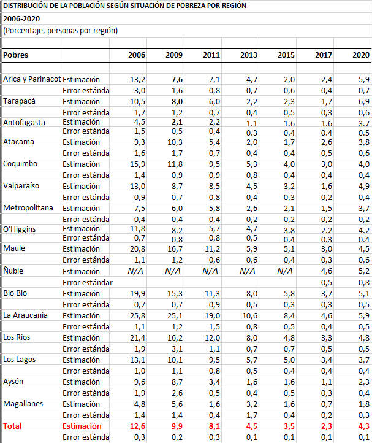

[(ver informe completo acá)](http://observatorio.ministeriodesarrollosocial.gob.cl/encuesta-casen-en-pandemia-2020)